# Visualizing Comparisons and Compositions

## 4.2 Circular plots: Pie and Donut charts

In this section, we will delve into circular data visualizations, particularly pie charts and donut plots, to demonstrate categorical data distribution. These types of plots can be quite polarizing in the data visualization community due to their tendency to distort data interpretation. However, when employed judiciously, they can offer an intuitive snapshot of proportions within a dataset.

- Delve into donut and pie charts with a note of caution: they’re visually enticing but can mislead.
- Recognize that bar plots often surpass these charts in delivering precise data interpretations.
- Understand that our brains prefer comparing lengths (like bars) over angles or areas (like pie slices).
- Remember, as data categories grow, pie and donut charts can get overly crowded and lose clarity.
- Acknowledge their inability to effectively display changes over time, unlike the adept bar plot.
- Use pie and donut charts sparingly, with a mindful eye on their potential to obscure data’s true story.

Before we can visualize the data, we must first aggregate it to get the total counts for each treatment outcome category, ensuring we have a clear representation of each segment of our dataset.

```r
outcome_totals <- tb_outcomes %>%
  group_by(outcome) %>%
  summarise(
    total_cases = sum(cases, na.rm = T))

outcome_totals
```

```
## # A tibble: 6 × 2
##   outcome     total_cases
##   <chr>             <dbl>
## 1 completed           573
## 2 cured              1506
## 3 died                130
## 4 failed               30
## 5 lost                 87
## 6 unevaluated          15
```

A pie chart is basically a round version of a single 100% stacked bar.

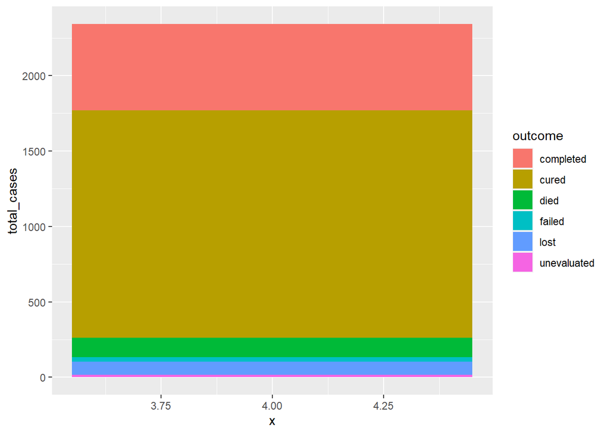

```r
# Single-bar chart (precursor to pie chart)
ggplot(outcome_totals,
       aes(x=4, # Set arbitrary x value
           y=total_cases,
           fill=outcome)) +
  geom_col()
```

- In ggplot2, we’ll explore how `coord_*()` functions can change a plot’s perspective, like tweaking aspect ratios or axis limits.
- We’ll transform our plot from linear to polar coordinates using `coord_polar()`, which will shape our data into slices for a pie chart.
- By mapping the `y` aesthetic to angles (using the `theta` argument), we’ll collaboratively create a visual that clearly displays the distribution of our categorical data.

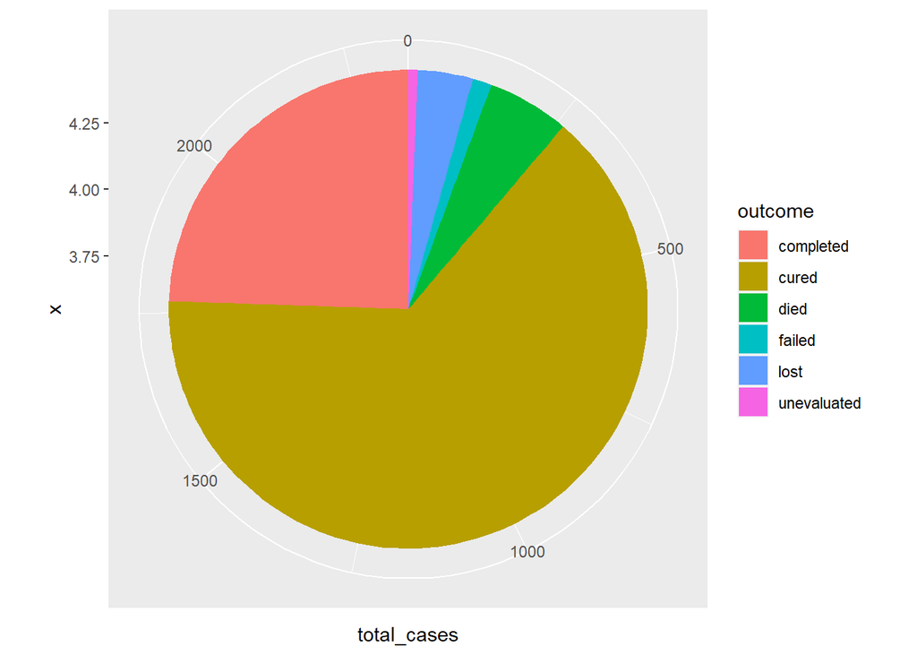

```r
# Basic pie chart
ggplot(outcome_totals,
       aes(x=4,
           y=total_cases,
           fill=outcome)) +
  geom_col() +
  coord_polar(theta = "y") # Change y axis to be circular
```

- Donut charts, or ring charts, offer a compelling twist on traditional pie charts and are within our reach using ggplot2 in R.
- We build these charts with a process akin to pie charts, but we add distinctive touches.
- By employing `geom_col()` we lay the groundwork with a bar chart.
- The transformation into a circle comes next with `coord_polar(theta = "y")`.
- With `xlim(c(0.2, 4 + 0.5))`, we’re setting the stage for the donut’s signature feature: its central void.
- The lower limit of `0.2` carves out the space for the donut’s hole, while `4.5` on the upper end ensures every category has its place.

A donut or ring chart can be created using `geom_col()`, `coord_polar(theta = "y")` and setting a x-axis limit with `xlim` like this:

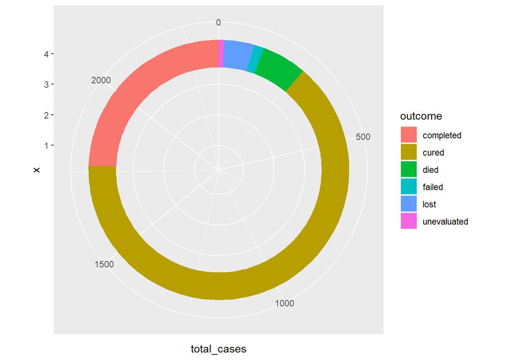

```r
# Make it a donut chart
ggplot(outcome_totals,
       aes(x=4,
           y=total_cases,
           fill=outcome)) +
  geom_col() +
  coord_polar(theta = "y") +
  xlim(c(0.2, 4 + 0.5)) # Set x-axis limits
```

- The x value controls hole size.
- Replace 4 with placeholder `hsize` which can be varied.
- The bigger the value the bigger the hole size. Note that the hole size must be bigger than 0.

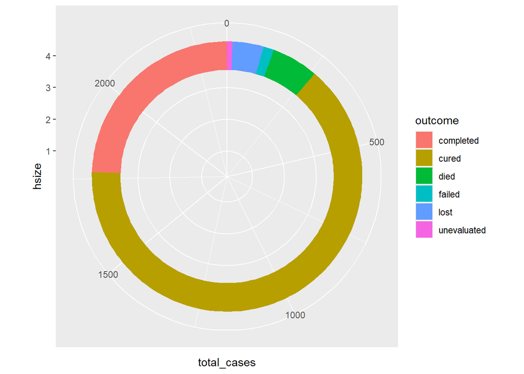

```r
# Set hole width
hsize <- 4

ggplot(outcome_totals,
       aes(x=hsize, y=total_cases, fill=outcome)) +
  geom_col() +
  coord_polar(theta = "y") +
  xlim(c(0.2, hsize + 0.5))
```

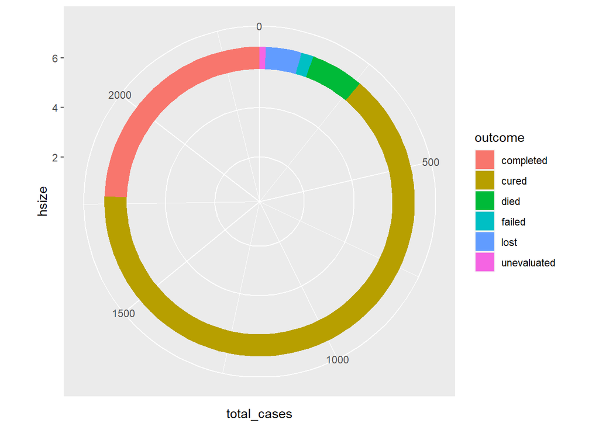

```r
# Increase the value to make the hole bigger
hsize <- 6

ggplot(outcome_totals, aes(x=hsize, y=total_cases, fill=outcome)) +
  geom_col() +
  coord_polar(theta = "y") +
  xlim(c(0.2, hsize + 0.5))
```

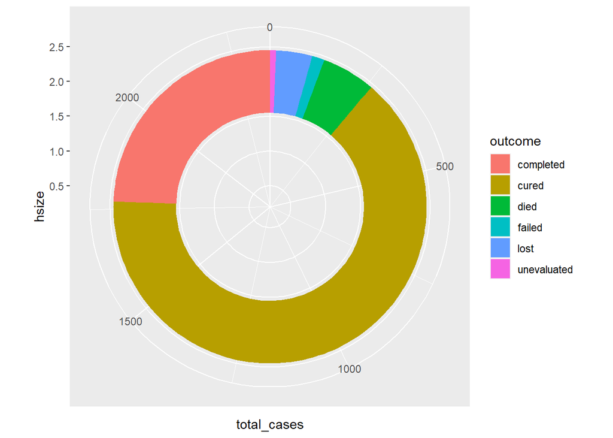

```r
# Decrease the value to make the hole smaller
hsize <- 2

ggplot(outcome_totals, aes(x=hsize, y=total_cases, fill=outcome)) +
  geom_col() +
  coord_polar(theta = "y") +
  xlim(c(0.2, hsize + 0.5))
```

The border, fill colors and the theme of the donut plot can be customized in several ways. The code below illustrates some customization options:

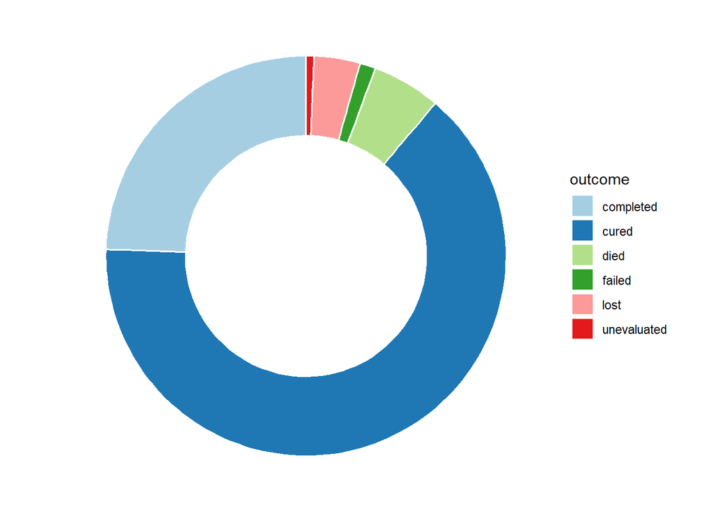

```r
# Improved aesthetics
ggplot(outcome_totals,
       aes(x=hsize, y=total_cases, fill=outcome)) +
  geom_col(color = "white", linewidth = 0.7) + # Add white borders
  coord_polar(theta = "y") +
  xlim(c(0.2, hsize + 0.5)) +
  scale_fill_brewer(palette = "Paired") + # Set color palette
  theme_void() # Remove background, grid, numeric labels
```

What do stacked bars, pies, and donuts have in common? They are all types of parts-to-whole charts! Along with making comparisons, visualizing what things are composed of is one of the most important applications of data visualization. These visualizations work for data that is grouped into multiple subcategories, where our aim is to see how much of the total each category makes up. Examining these “parts-to-whole” relationships can provide insight into demographics, budget allocation, levels of agreement, and more.

**Practice Question:** The whole picture

Using the `tb_outcomes` dataset in R, create a visual representation that compares the proportion of tuberculosis cases by outcome across different types of diagnoses. Your visualization should:

1. Group the data by `outcome` and `diagnosis_type`.
2. Summarize the total number of `cases` for each group, accounting for possible missing values (`NA`s).
3. Display this information in a series of donut charts, one for each diagnosis type, showing the proportion of each outcome within the diagnosis type.
4. Ensure the charts have a clean look with `**white**` borders around the segments and no background or gridlines.
5. Arrange the individual donut charts for each diagnosis type using `facet_wrap`.

Write the R code to create this visualization.

```r
# PQ4 answer
tb_outcomes %>%
  group_by(------, -------) %>%
  summarise(
    total_cases = sum(-----, -----)) %>%
ggplot(aes(x=----, y=------, fill=-------)) +
  geom_col(color = ------, position = -------) +
  coord_polar(theta = "y") +
  xlim(c(0.2, ------ + 0.5)) +
  theme_void() +
  -------------
```

```
## Error: <text>:3:18: unexpected ','
## 2: tb_outcomes %>%
## 3:   group_by(------,
##                     ^
```

# References

Some material in this lesson was adapted from the following sources:

- Horst, Allison. “Allisonhorst/Dplyr-Learnr: A Colorful Introduction to Some Common Functions in Dplyr, Part of the Tidyverse.” GitHub. Accessed April 6, 2022. https://github.com/allisonhorst/dplyr-learnr.

This work is licensed under the [Creative Commons Attribution Share Alike](https://creativecommons.org/licenses/by-sa/4.0/) license.